# Homework ASM (SoSe 2021) – Week 13

Marc Blauert

2021-07-09

Tasks: McElreath Ch. 14.7, Ex. 14E1, 14M1-2

# 1 14E1

Add to the following model (initial model) varying slopes on the predictor x (adjusted model).

## 1.1 Initial model

$$\begin{align*}
y_i &\sim {\sf Normal}(\mu_i, \sigma) \\
\mu_i &= \alpha_{\text{GROUP[i]}} + \beta x_i \\
\alpha_{\text{j}} &\sim {\sf Normal}(\alpha, \sigma_{\alpha}) \\
\alpha &\sim {\sf Normal}(0, 10) \\
\beta &\sim {\sf Normal}(0, 1) \\
\sigma, \sigma_{\alpha} &\sim {\sf Exponential}(1) \\
\end{align*}$$

## 1.2 Adjusted model

$$\begin{align*}
y_i &\sim {\sf Normal}(\mu_i, \sigma) \\
\mu_i & = \alpha_{\text{GROUP}[i]} + \beta_{\text{GROUP}[i]} x_i \\
\alpha_{\text{j}} &\sim {\sf Normal}(\alpha, \sigma_{\alpha}) \\
\beta_{\text{j}} &\sim {\sf Normal}(\beta, \sigma_{\beta}) \\
\alpha &\sim {\sf Normal}(0, 10) \\
\beta &\sim {\sf Normal}(0, 1) \\
\sigma, \sigma_{\alpha}, \sigma_{\beta} &\sim {\sf Exponential}(1) \\
\end{align*}$$

# 2 14M1

Repeat the café robot simulation from the beginning of the chapter.This time, set `rho` to zero, so that there is no correlation between intercepts and slopes. How does the posterior distribution of the correlation reflect this change in the underlying simulation?

## 2.1 Simulate varying slopes and intercepts

```r
# Note: Simulation copied from Section 14.1 in the brms bookdown

set.seed(5) # to replicate example

a <- 3.5 # average morning wait time
b <- -1 # average difference afternoon wait time
sigma_a <- 1 # std dev in intercepts
sigma_b <- 0.5 # std dev in slopes
mu <- c(a, b)

# IMPORTANT: Here we make the change to zero correlation
rho <- 0 # correlation between intercepts and slopes as zero

sigmas <- c(sigma_a, sigma_b) # standard deviations
rho <- matrix(c(1, rho,
                rho, 1), nrow = 2) # correlation matrix
sigma <- diag(sigmas) %*% rho %*% diag(sigmas) # matrix multiply to get covariance matrix

n_cafes <- 20 # number of cafés

vary_effects <-
  mvrnorm(n_cafes, mu, sigma) %>%
  data.frame() %>%
  set_names("a_cafe", "b_cafe") # df with a_cafe as café-specific intercepts; and b_cafe as café-specific slopes

cor(vary_effects$a_cafe, vary_effects$b_cafe)
```

```
## [1] 0.04330653
```

The correlation coefficient at the end of the code section shows that the varying intercepts and the varying slopes are now merely uncorrelated. The fact that the correlation does not quite approach zero is only due to the relatively small number of cafés in the sample. With a larger number of cafés, the correlation would be closer to zero.

## 2.2 Simulate the actual data

```r
set.seed(22) # for replication

n_visits <- 10
sigma    <-  0.5  # std dev within cafes

d <-
  vary_effects %>%
  mutate(cafe = 1:n_cafes) %>%
  expand(nesting(cafe, a_cafe, b_cafe), visit = 1:n_visits) %>%
  mutate(afternoon = rep(0:1, times = n() / 2)) %>%
  mutate(mu = a_cafe + b_cafe * afternoon) %>%
  mutate(wait = rnorm(n = n(), mean = mu, sd = sigma)) # 20 cafés with 10 visits each

str(d)
```

```
## tibble [200 × 7] (S3: tbl_df/tbl/data.frame)
##  $ cafe     : int [1:200] 1 1 1 1 1 1 1 1 1 1 ...
##  $ a_cafe   : num [1:200] 4.34 4.34 4.34 4.34 4.34 ...
##  $ b_cafe   : num [1:200] -1.45 -1.45 -1.45 -1.45 -1.45 ...
##  $ visit    : int [1:200] 1 2 3 4 5 6 7 8 9 10 ...
##  $ afternoon: int [1:200] 0 1 0 1 0 1 0 1 0 1 ...
##  $ mu       : num [1:200] 4.34 2.89 4.34 2.89 4.34 ...
##  $ wait     : num [1:200] 4.08 4.13 4.84 3.04 4.24 ...
```

## 2.3 Fit the model

$$\begin{align*}
\text{wait}_i & \sim \operatorname{Normal}(\mu_i, \sigma) \\
\mu_i & = \alpha_{\text{café}[i]} + \beta_{\text{café}[i]} \text{afternoon}_i \\
\begin{bmatrix} \alpha_\text{j} \\ \beta_\text{j} \end{bmatrix} & \sim \operatorname{MVNormal} \begin{pmatrix} \begin{bmatrix} \alpha \\ \beta \end{bmatrix}, \mathbf \Sigma \end{pmatrix} \\
\mathbf \Sigma & = \begin{bmatrix} \sigma_\alpha & 0 \\ 0 & \sigma_\beta \end{bmatrix} \mathbf R \begin{bmatrix} \sigma_\alpha & 0 \\ 0 & \sigma_\beta \end{bmatrix} \\
\alpha & \sim \operatorname{Normal}(5, 2) \\
\beta & \sim \operatorname{Normal}(-1, 0.5) \\
\sigma, \sigma_\alpha, \sigma_\beta & \sim \operatorname{Exponential}(1) \\
\mathbf R & \sim \operatorname{LKJcorr}(2),
\end{align*}$$

(Note: Here I used the alpha_j and beta_j again; not entirely sure if this is the formally correct way to write it. In the bookdown, alpha_café and beta_café was used. But possibly it was only wrongly copied from McElreth’s book.)

```r
b14.1 <-
  brm(data = d,
      family = gaussian,
      wait ~ 1 + afternoon + (1 + afternoon | cafe),
      prior = c(prior(normal(5, 2), class = Intercept),
                prior(normal(-1, 0.5), class = b),
                prior(exponential(1), class = sd),
                prior(exponential(1), class = sigma),
                prior(lkj(2), class = cor)),
      iter = 2000, warmup = 1000, chains = 4, cores = 4,
      file = "fits/b14.01")

summary(b14.1)
```

```
##  Family: gaussian
##   Links: mu = identity; sigma = identity
## Formula: wait ~ 1 + afternoon + (1 + afternoon | cafe)
##    Data: d (Number of observations: 200)
## Samples: 4 chains, each with iter = 2000; warmup = 1000; thin = 1;
##          total post-warmup samples = 4000
##
## Group-Level Effects:
## ~cafe (Number of levels: 20)
##                          Estimate Est.Error l-95% CI u-95% CI Rhat Bulk_ESS
## sd(Intercept)                0.99      0.18     0.71     1.40 1.00     1003
## sd(afternoon)                0.64      0.14     0.41     0.95 1.00     1534
## cor(Intercept,afternoon)    -0.05      0.22    -0.48     0.39 1.00     2259
##                          Tail_ESS
## sd(Intercept)                1535
## sd(afternoon)                2706
## cor(Intercept,afternoon)     2673
##
## Population-Level Effects:
##           Estimate Est.Error l-95% CI u-95% CI Rhat Bulk_ESS Tail_ESS
## Intercept     3.71      0.23     3.28     4.16 1.00      621     1041
## afternoon    -1.10      0.15    -1.40    -0.79 1.00     1687     2040
##
## Family Specific Parameters:
##       Estimate Est.Error l-95% CI u-95% CI Rhat Bulk_ESS Tail_ESS
## sigma     0.47      0.03     0.43     0.53 1.00     4032     3335
##
## Samples were drawn using sampling(NUTS). For each parameter, Bulk_ESS
## and Tail_ESS are effective sample size measures, and Rhat is the potential
## scale reduction factor on split chains (at convergence, Rhat = 1).
```

## 2.4 Plot the posterior distribution of correlation between intercepts and slopes

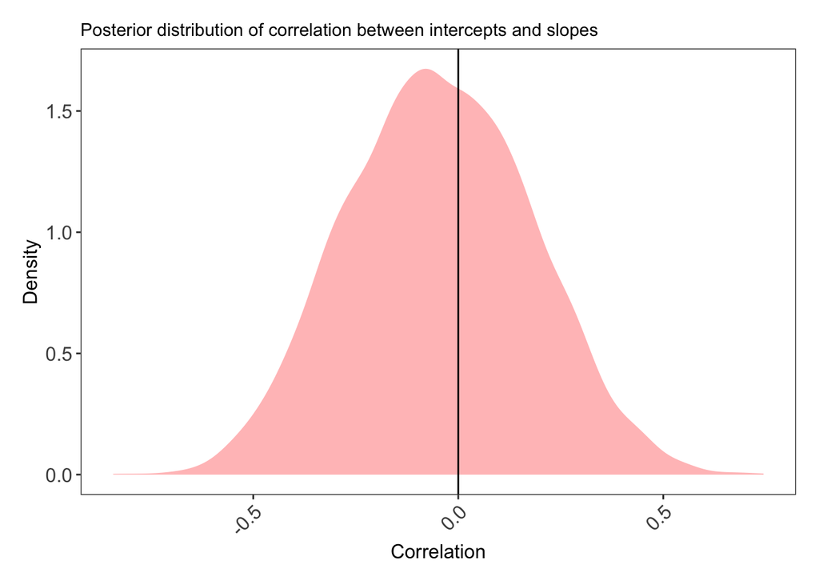

```r
post <- posterior_samples(b14.1)

post %>%
  ggplot() +
  geom_density(aes(x = cor_cafe__Intercept__afternoon),
               fill = "red",
               color = "transparent",
               alpha = 0.3) +
  geom_vline(xintercept = 0, color = "black") +
  theme_plots() +
  labs(subtitle = "Posterior distribution of correlation between intercepts and slopes",
  x = "Correlation", y = "Density")
```

The graph shows that the posterior correlation distribution is centered around zero and that the sampling reflects the previously estimated correlation coefficient close to zero. As mentioned previously, using a larger number of cafés would result in the residual difference to decrease even more.

# 3 14M2

Fit a multilevel model (with no multivariate correlation between intercept and slope) to the simulated café data and use LOO (WAIC) to compare this model to the model from the chapter (the one that uses a multivariate Gaussian prior). Explain the result.

## 3.1 Re-simulate data with varying intercepts and slopes

```r
set.seed(5)

a <- 3.5
b <- -1
sigma_a <- 1
sigma_b <- 0.5
mu <- c(a, b)

rho <- -0.7 # IMPORTANT: Here we make the change back to a correlation of -0.7

sigmas <- c(sigma_a, sigma_b)
rho <- matrix(c(1, rho,
                rho, 1), nrow = 2)
sigma <- diag(sigmas) %*% rho %*% diag(sigmas)

n_cafes <- 20

vary_effects <-
  mvrnorm(n_cafes, mu, sigma) %>%
  data.frame() %>%
  set_names("a_cafe", "b_cafe")

cor(vary_effects$a_cafe, vary_effects$b_cafe)
```

```
## [1] -0.5721537
```

```r
set.seed(22)

n_visits <- 10
sigma <- 0.5

d <-
  vary_effects %>%
  mutate(cafe = 1:n_cafes) %>%
  expand(nesting(cafe, a_cafe, b_cafe), visit = 1:n_visits) %>%
  mutate(afternoon = rep(0:1, times = n() / 2)) %>%
  mutate(mu = a_cafe + b_cafe * afternoon) %>%
  mutate(wait = rnorm(n = n(), mean = mu, sd = sigma))

str(d)
```

```
## tibble [200 × 7] (S3: tbl_df/tbl/data.frame)
##  $ cafe     : int [1:200] 1 1 1 1 1 1 1 1 1 1 ...
##  $ a_cafe   : num [1:200] 4.22 4.22 4.22 4.22 4.22 ...
##  $ b_cafe   : num [1:200] -1.61 -1.61 -1.61 -1.61 -1.61 ...
##  $ visit    : int [1:200] 1 2 3 4 5 6 7 8 9 10 ...
##  $ afternoon: int [1:200] 0 1 0 1 0 1 0 1 0 1 ...
##  $ mu       : num [1:200] 4.22 2.61 4.22 2.61 4.22 ...
##  $ wait     : num [1:200] 3.97 3.86 4.73 2.76 4.12 ...
```

## 3.2 Fit model with multivariate Gaussian prior (from chapter)

(For model equation compare Section 2.3.)

```r
b14.2 <-
  brm(data = d,
      family = gaussian,
      wait ~ 1 + afternoon + (1 + afternoon | cafe),
      prior = c(prior(normal(5, 2), class = Intercept),
                prior(normal(-1, 0.5), class = b),
                prior(exponential(1), class = sd),
                prior(exponential(1), class = sigma),
                prior(lkj(2), class = cor)),
      iter = 2000, warmup = 1000, chains = 4, cores = 4,
      file = "fits/b14.02")

summary(b14.2)
```

```
##  Family: gaussian
##   Links: mu = identity; sigma = identity
## Formula: wait ~ 1 + afternoon + (1 + afternoon | cafe)
##    Data: d (Number of observations: 200)
## Samples: 4 chains, each with iter = 2000; warmup = 1000; thin = 1;
##          total post-warmup samples = 4000
##
## Group-Level Effects:
## ~cafe (Number of levels: 20)
##                          Estimate Est.Error l-95% CI u-95% CI Rhat Bulk_ESS
## sd(Intercept)                0.95      0.17     0.70     1.35 1.00     1105
## sd(afternoon)                0.59      0.13     0.39     0.89 1.00     1403
## cor(Intercept,afternoon)    -0.50      0.18    -0.80    -0.09 1.00     1940
##                          Tail_ESS
## sd(Intercept)                2202
## sd(afternoon)                1522
## cor(Intercept,afternoon)     2515
##
## Population-Level Effects:
##           Estimate Est.Error l-95% CI u-95% CI Rhat Bulk_ESS Tail_ESS
## Intercept     3.66      0.22     3.23     4.08 1.00      641     1183
## afternoon    -1.13      0.14    -1.41    -0.85 1.00     1267     2152
##
## Family Specific Parameters:
##       Estimate Est.Error l-95% CI u-95% CI Rhat Bulk_ESS Tail_ESS
## sigma     0.47      0.03     0.42     0.53 1.00     3808     2590
##
## Samples were drawn using sampling(NUTS). For each parameter, Bulk_ESS
## and Tail_ESS are effective sample size measures, and Rhat is the potential
## scale reduction factor on split chains (at convergence, Rhat = 1).
```

## 3.3 Fit model with no multivariate Gaussian prior

$$\begin{align*}
\text{wait}_i &\sim {\sf Normal}(\mu_i, \sigma) \\
\mu_i & = \alpha_{\text{café}[i]} + \beta_{\text{café}[i]} \text{afternoon}_i \\
\alpha_{\text{j}} &\sim {\sf Normal}(\alpha, \sigma_{\alpha}) \\
\beta_{\text{j}} &\sim {\sf Normal}(\beta, \sigma_{\beta}) \\
\alpha &\sim {\sf Normal}(0, 10) \\
\beta &\sim {\sf Normal}(0, 10) \\
\sigma, \sigma_{\alpha}, \sigma_{\beta} &\sim {\sf Exponential}(1) \\
\end{align*}$$

Hint provided: To model NO correlation between the group-level parameters, use “||” instead of “|” in front of the grouping variable (https://cran.r-project.org/web/packages/brms/vignettes/brms_multilevel.pdf).

```r
b14.3 <-
  brm(data = d,
      family = gaussian,
      wait ~ 1 + afternoon + (1 + afternoon || cafe), # Prevent consideration of the correlation between intercept and slope
      prior = c(prior(normal(0, 10), class = Intercept),
                prior(normal(0, 10), class = b),
                prior(exponential(1), class = sd),
                prior(exponential(1), class = sigma)),
      iter = 2000, warmup = 1000, chains = 4, cores = 4,
      file = "fits/b14.03")

summary(b14.3)
```

```
##  Family: gaussian
##   Links: mu = identity; sigma = identity
## Formula: wait ~ 1 + afternoon + (1 + afternoon || cafe)
##    Data: d (Number of observations: 200)
## Samples: 4 chains, each with iter = 2000; warmup = 1000; thin = 1;
##          total post-warmup samples = 4000
##
## Group-Level Effects:
## ~cafe (Number of levels: 20)
##               Estimate Est.Error l-95% CI u-95% CI Rhat Bulk_ESS Tail_ESS
## sd(Intercept)     0.93      0.17     0.67     1.31 1.00     1401     2275
## sd(afternoon)     0.57      0.13     0.36     0.85 1.00     1578     2575
##
## Population-Level Effects:
##           Estimate Est.Error l-95% CI u-95% CI Rhat Bulk_ESS Tail_ESS
## Intercept     3.63      0.21     3.24     4.04 1.00      776     1486
## afternoon    -1.14      0.15    -1.43    -0.85 1.00     1621     2247
##
## Family Specific Parameters:
##       Estimate Est.Error l-95% CI u-95% CI Rhat Bulk_ESS Tail_ESS
## sigma     0.48      0.03     0.43     0.53 1.00     3456     2659
##
## Samples were drawn using sampling(NUTS). For each parameter, Bulk_ESS
## and Tail_ESS are effective sample size measures, and Rhat is the potential
## scale reduction factor on split chains (at convergence, Rhat = 1).
```

The results from the the two models with (`b14.2`) and without (`b14.3`) the multivariate Gaussian prior are largely the same. It is therefore to be expected that the model comparison rates the two models as more or less equally good in their predictive ability.

## 3.4 Model comparison

```r
b14.2 <- add_criterion(b14.2, c("loo", "waic"))
b14.3 <- add_criterion(b14.3, c("loo", "waic"))

loo_compare(b14.2, b14.3, criterion = "loo") %>% print(simplify = T) # use of LOO since with WAIC 23 observations have a pareto_k estimate larger than 0.4
```

```
##       elpd_diff se_diff
## b14.2  0.0       0.0
## b14.3 -1.1       1.1
```